# Regressão linear na prática

## Dados da CAPES sobre avaliação da pós-graduação

A CAPES é um órgão do MEC que tem a atribuição de acompanhar a pós-graduação na universidade brasileira. Uma das formas que ela encontrou de fazer isso e pela qual ela é bastante criticada é através de uma avaliação quantitativa a cada x anos (era 3, mudou para 4).

Usaremos dados da penúltima avaliação da CAPES:

```r
cacc = read_projectdata()

glimpse(cacc)
```

```
## Observations: 73
## Variables: 31
## $ Instituicao                  <chr> "UNIVERSIDADE FEDERAL DO AMAZONAS...
## $ Programa                     <chr> "INFORMÁTICA (12001015012P2)", "C...
## $ Nível                        <int> 5, 4, 3, 3, 3, 5, 4, 3, 3, 3, 5, ...
## $ Sigla                        <chr> "UFAM", "UFPA", "UFMA", "UEMA", "...
## $ `Tem doutorado`              <chr> "Sim", "Sim", "Não", "Não", "Não"...
## $ `Docentes colaboradores`     <dbl> 0.25, 5.50, 3.00, 6.25, 1.75, 2.0...
## $ `Docentes permanentes`       <dbl> 24.75, 14.00, 10.00, 14.00, 9.50,...
## $ `Docentes visitantes`        <dbl> 0.00, 0.00, 0.00, 0.00, 0.00, 0.7...
## $ `Resumos em conf`            <int> 20, 23, 15, 5, 4, 10, 6, 136, 0, ...
## $ `Resumos expandidos em conf` <int> 25, 24, 7, 10, 1, 68, 9, 13, 4, 6...
## $ `Artigos em conf`            <int> 390, 284, 115, 73, 150, 269, 179,...
## $ Dissertacoes                 <int> 108, 77, 50, 25, 31, 75, 60, 129,...
## $ Teses                        <int> 14, 0, 0, 0, 0, 24, 5, 0, 0, 0, 2...
```

[output cut: 18 more lines]

### Produção e produtividade de artigos

Uma das maneiras de avaliar a produção dos docentes que a CAPES utiliza é quantificando a produção de artigos pelos docentes. Os artigos são categorizados em extratos ordenados (A1 é o mais alto), e separados entre artigos em conferências e periódicos. Usaremos para esse lab a produção em periódicos avaliados com A1, A2 e B1.

```r
cacc = cacc %>%
  mutate(producao = (periodicos_A1 + periodicos_A2 + periodicos_B1),
         produtividade = producao / `Docentes permanentes`,
         mestrados = Dissertacoes,
         doutorados = Teses,
         mestrados_pprof = mestrados / `Docentes permanentes`,
         doutorados_pprof = doutorados / `Docentes permanentes`)
```

### EDA

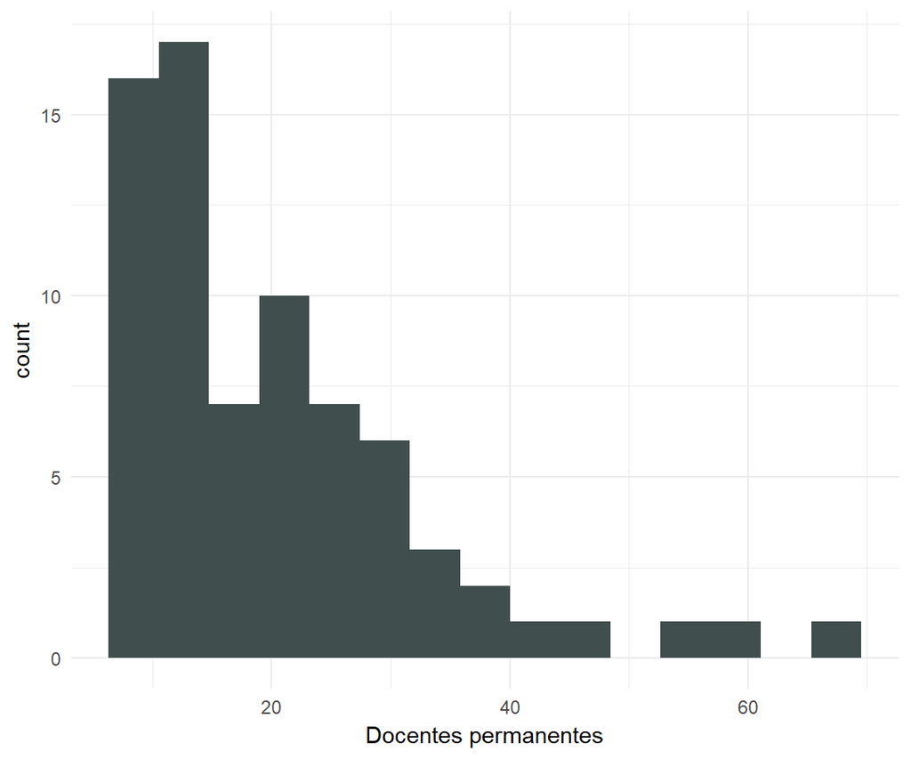

```r
cacc %>%
  ggplot(aes(x = `Docentes permanentes`)) +
  geom_histogram(bins = 15, fill = paleta[1])
```

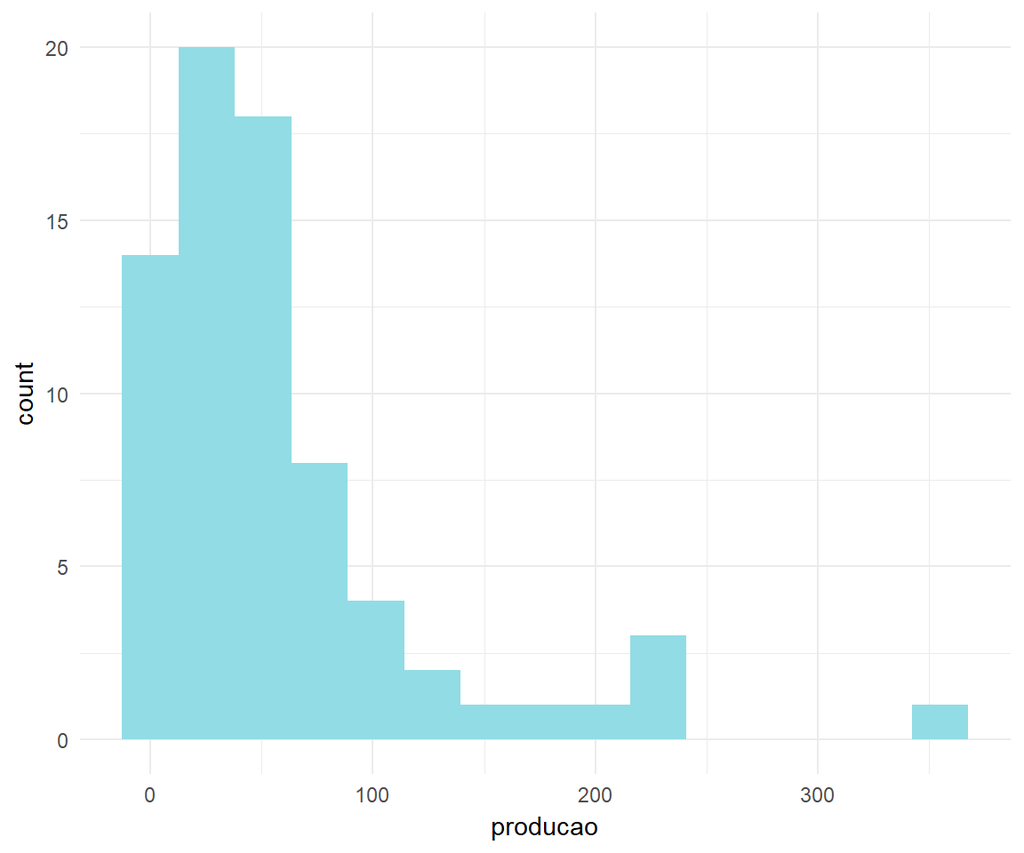

```r
cacc %>%
  ggplot(aes(x = producao)) +
  geom_histogram(bins = 15, fill = paleta[2])
```

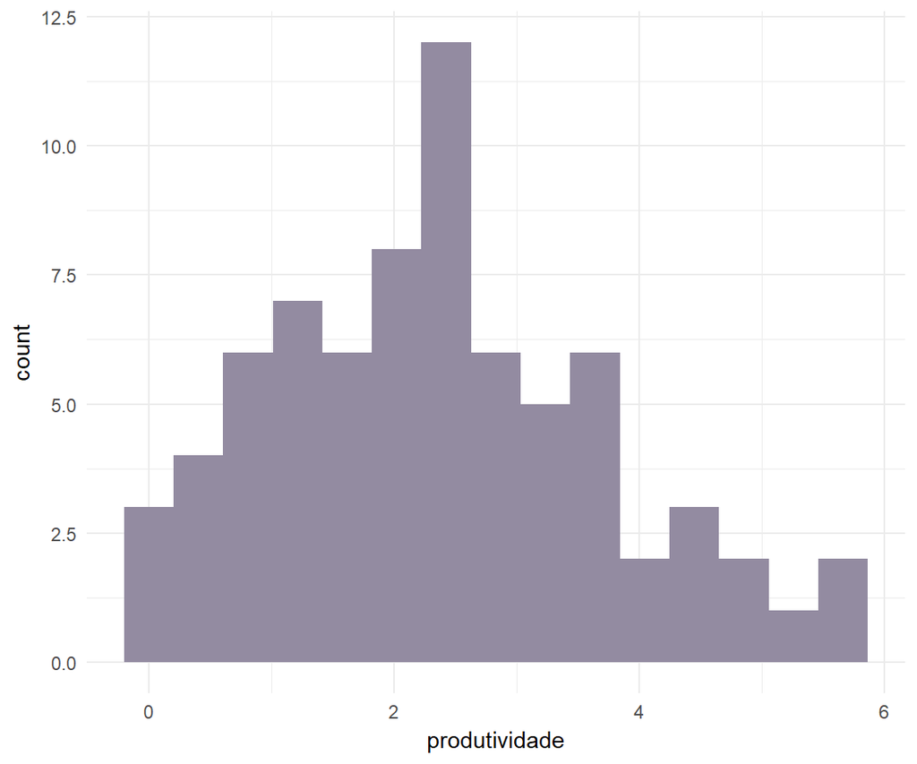

```r
cacc %>%
  ggplot(aes(x = produtividade)) +
  geom_histogram(bins = 15, fill = paleta[3])
```

Se quisermos modelar o efeito do tamanho do programa em termos de docentes (permanentes) na quantidade de artigos publicados, podemos usar regressão.

**Importante**: sempre queremos ver os dados antes de fazermos qualquer modelo ou sumário:

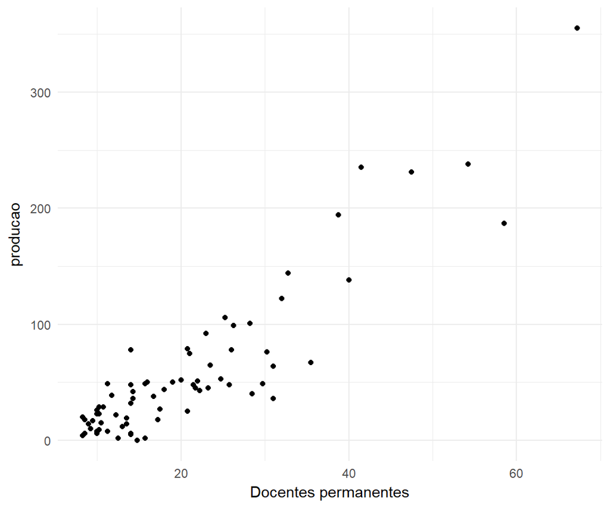

```r
cacc %>%
  ggplot(aes(x = `Docentes permanentes`, y = producao)) +
  geom_point()
```

```r
# This block was derivated from the previous one to try another view with same scale on both axis.
#cacc %>%
#  ggplot(aes(x = `Docentes permanentes`, y = producao)) +
#  geom_point() +
#  scale_x_continuous(limits = c(0,300))
```

Parece que existe uma relação. Vamos criar um modelo então:

```r
modelo1 = lm(producao ~ `Docentes permanentes`, data = cacc)

tidy(modelo1, conf.int = TRUE, conf.level = 0.95)
```

| term | estimate | std.error | statistic | p.value | conf.low | conf.high |
| --- | --- | --- | --- | --- | --- | --- |
| (Intercept) | -41.27309 | 6.5299245 | -6.320607 | 2.014731e-08 | -54.293387 | -28.252788 |
| `Docentes permanentes` | 4.81337 | 0.2725331 | 17.661601 | 1.088465e-27 | 4.269955 | 5.356786 |

```r
glance(modelo1)
```

| r.squared | adj.r.squared | sigma | statistic | p.value | df | logLik | AIC | BIC | deviance | df.residual |
| --- | --- | --- | --- | --- | --- | --- | --- | --- | --- | --- |
| 0.8145886 | 0.8119771 | 28.37407 | 311.9322 | 1.088465e-27 | 2 | -346.7883 | 699.5766 | 706.4479 | 57161.22 | 71 |

Para visualizar o modelo:

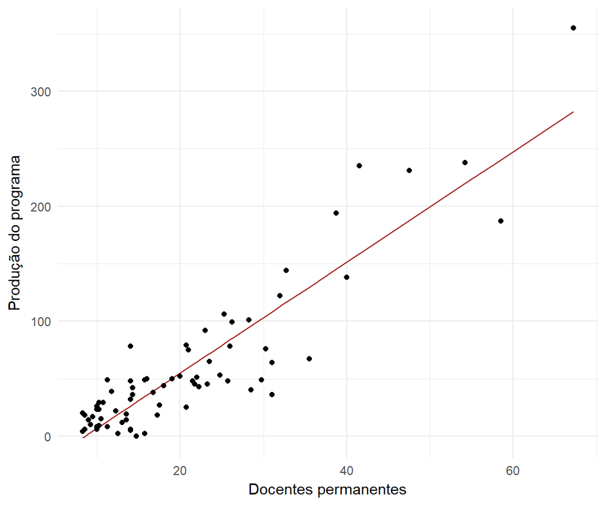

```r
cacc_augmented = cacc %>%
  add_predictions(modelo1)

cacc_augmented %>%
  ggplot(aes(x = `Docentes permanentes`)) +
  geom_line(aes(y = pred), colour = "brown") +
  geom_point(aes(y = producao)) +
  labs(y = "Produção do programa")
```

Se considerarmos que temos apenas uma amostra de todos os programas de pós em CC no Brasil, o que podemos inferir a partir desse modelo sobre a relação entre número de docentes permanentes e produção de artigos em programas de pós?

Normalmente reportaríamos o resultado da seguinte maneira, substituindo VarIndepX e todos os x’s e y’s pelos nomes e valores de fato:

> Regressão múltipla foi utilizada para analisar se VarIndep1 e VarIndep2 tem uma associação significativa com VarDep. Os resultados da regressão indicam que um modelo com os 2 preditores no formato VarDep = XXX.VarIndep1 + YYY.VarIndep2 explicam XX,XX% da variância da variável de resposta (R2 = XX,XX). VarIndep1, medida como/em [unidade ou o que é o 0 e o que é 1] tem uma relação significativa com o erro (b = [yy,yy; zz,zz], IC com 95%), assim como VarIndep2 medida como [unidade ou o que é o 0 e o que é 1] (b = [yy,yy; zz,zz], IC com 95%). O aumento de 1 unidade de VarIndep1 produz uma mudança de xxx em VarDep, enquanto um aumento…

Produza aqui a sua versão desse texto, portanto:

Regressão linear foi utilizada para analisar se **a quantidade de docentes permanentes num dado programa de pós-graduação** tem uma associação significativa com **a produção do respectivo programa**, esta última medida em termos da quantidade de publicações em períodicos dos extratos A1, A2 e B1. Os resultados da regressão indicam que um modelo com **1 preditor** no formato **producao = -41,27 + 4,81 . docentes_permanentes** explicam **81,46%** da variância da variável de resposta (R2 = **81,46%**). A **quantidade de docentes**, medida **em pessoas que integram o programa**, tem uma relação significativa com o erro (b = **[4,27; 5,36]**, IC com 95%). O aumento de 1 unidade de **quantidade de docentes permanentes** gera uma mudança positiva de **4,81 na produção do programa**.

Dito isso, o que significa a relação que você encontrou na prática para entendermos os programas de pós graduação no Brasil? E algum palpite de por que a relação que encontramos é forte?

Pela análise realizada, verificamos que a quantidade de docentes permanentes e a produção de um programa são duas características associadas positivamente de maneira significativa. Isso é o mesmo que dizer que o crescimento de uma ocorre junto com o crescimento da outra, precisamente a uma taxa estatisticamente esperada de +4,81 unidades de produção para cada docente a mais no programa. Todavia, precisamos ter cuidado na compreensão desse resultado, pois apesar de mencionarmos uma em função da outra, não podemos, no entanto, afirmar que haja qualquer relação de causalidade entre elas, mas apenas que elas têm alguma espécie de relacionamento. Por outro lado, podemos imaginar que a quantidade de docente, de fato, implique em maiores quantitativos de produção, uma vez que havendo mais pessoas, espera-se realmente que elas estejam trabalhando e publicando mais conteúdo.

## Mais fatores

E se considerarmos também o número de alunos?

```r
modelo2 = lm(producao ~ `Docentes permanentes` + mestrados + doutorados, data = cacc)

tidy(modelo2, conf.int = TRUE, conf.level = 0.95)
```

| term | estimate | std.error | statistic | p.value | conf.low | conf.high |
| --- | --- | --- | --- | --- | --- | --- |
| (Intercept) | -14.3663077 | 7.45407703 | -1.927309 | 5.805909e-02 | -29.2367845 | 0.5041691 |
| `Docentes permanentes` | 3.4997112 | 0.45965441 | 7.613788 | 1.015822e-10 | 2.5827257 | 4.4166967 |
| mestrados | -0.1949515 | 0.08159627 | -2.389221 | 1.962240e-02 | -0.3577316 | -0.0321714 |
| doutorados | 1.0007711 | 0.18309265 | 5.465927 | 6.874998e-07 | 0.6355112 | 1.3660309 |

```r
glance(modelo2)
```

| r.squared | adj.r.squared | sigma | statistic | p.value | df | logLik | AIC | BIC | deviance | df.residual |
| --- | --- | --- | --- | --- | --- | --- | --- | --- | --- | --- |
| 0.8706642 | 0.8650409 | 24.03905 | 154.8316 | 1.416348e-30 | 4 | -333.6422 | 677.2845 | 688.7368 | 39873.45 | 69 |

Visualizar o modelo com muitas variáveis independentes fica mais difícil

```r
para_plotar_modelo = cacc %>%
  data_grid(producao = seq_range(producao, 10), # Crie um vetor de 10 valores no range
            `Docentes permanentes` = seq_range(`Docentes permanentes`, 4),
            # mestrados = seq_range(mestrados, 3),
            mestrados = median(mestrados),
            doutorados = seq_range(doutorados, 3)) %>%
  add_predictions(modelo2)

glimpse(para_plotar_modelo)
```

```
## Observations: 120
## Variables: 5
## $ producao               <dbl> 0.00000, 0.00000, 0.00000, 0.00000, 0.0...
## $ `Docentes permanentes` <dbl> 8.25000, 8.25000, 8.25000, 27.91667, 27...
## $ mestrados              <int> 58, 58, 58, 58, 58, 58, 58, 58, 58, 58,...
## $ doutorados             <dbl> 0, 76, 152, 0, 76, 152, 0, 76, 152, 0, ...
## $ pred                   <dbl> 3.199123, 79.257725, 155.316327, 72.026...
```

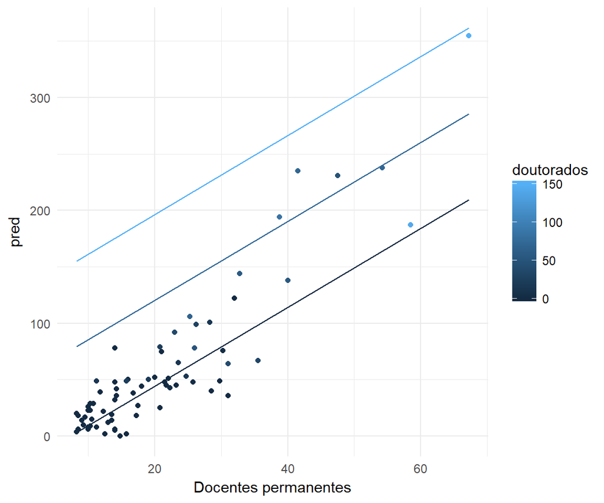

```r
para_plotar_modelo %>%
  ggplot(aes(x = `Docentes permanentes`, y = pred)) +
  geom_line(aes(group = doutorados, colour = doutorados)) +
  # facet_grid(. ~ as.factor(mestrados)) +
  geom_point(data = cacc, aes(y = producao, colour = doutorados))
```

Considerando agora esses três fatores, o que podemos dizer sobre como cada um deles se relaciona com a produção de um programa de pós em CC? E sobre o modelo? Ele explica mais que o modelo 1?

## Agora produtividade

Diferente de medirmos produção (total produzido), é medirmos produtividade (produzido / utilizado). Abaixo focaremos nessa análise. Para isso crie um modelo que investiga como um conjunto de fatores que você julga que são relevantes se relacionam com a produtividade dos programas. Crie um modelo que avalie como *pelo menos 3 fatores* se relacionam com a produtividade de um programa. Pode reutilizar fatores que já definimos e analizamos para produção. Mas cuidado para não incluir fatores que sejam função linear de outros já incluídos (ex: incluir A, B e um tercero C=A+B)

Produza abaixo o modelo e um texto que comente (i) o modelo, tal como os que fizemos antes, e (ii) as implicações - o que aprendemos sobre como funcionam programas de pós no brasil?.

```r
modelo3 = lm(produtividade ~ `Docentes permanentes` + mestrados + doutorados, data = cacc)

tidy(modelo3, conf.int = TRUE, conf.level = 0.95)
```

| term | estimate | std.error | statistic | p.value | conf.low | conf.high |
| --- | --- | --- | --- | --- | --- | --- |
| (Intercept) | 1.695838919 | 0.343071639 | 4.943104 | 5.178040e-06 | 1.011429726 | 2.380248112 |
| `Docentes permanentes` | 0.032265304 | 0.021155455 | 1.525153 | 1.317917e-01 | -0.009938674 | 0.074469282 |
| mestrados | -0.004487973 | 0.003755443 | -1.195058 | 2.361558e-01 | -0.011979877 | 0.003003932 |
| doutorados | 0.022936354 | 0.008426784 | 2.721840 | 8.211856e-03 | 0.006125381 | 0.039747327 |

```r
glance(modelo3)
```

| r.squared | adj.r.squared | sigma | statistic | p.value | df | logLik | AIC | BIC | deviance | df.residual |
| --- | --- | --- | --- | --- | --- | --- | --- | --- | --- | --- |
| 0.3771308 | 0.3500496 | 1.10639 | 13.92589 | 3.394326e-07 | 4 | -108.9061 | 227.8122 | 239.2645 | 84.46284 | 69 |

De fato isso é esperado, pois a produtividade é numericamente falando a produção média esperada por pessoa, logo o aumento de pessoas aumenta sim o resultado geral, mas em geral não se pode esperar que uma pessoa venha trazer impacto relevante na produtividade de outras pessoas. Para isso devemos buscar fatores externos às pessoas e isso faremos a seguir.

```r
meu_cacc = cacc %>% mutate(atratividade = `Docentes colaboradores`/`Docentes permanentes`,
                           docentes_total = `Docentes permanentes` + `Docentes colaboradores` + `Docentes visitantes`,
                           pessoas_total = docentes_total + mestrados + doutorados,
                           periodicos_A = periodicos_A1 + periodicos_A2)

modelo3b = lm(produtividade ~ `Docentes permanentes` + periodicos_A + `Nível` + `Tem doutorado` + doutorados_pprof, data = meu_cacc)

tidy(modelo3b, conf.int = TRUE, conf.level = 0.95)
```

| term | estimate | std.error | statistic | p.value | conf.low | conf.high |
| --- | --- | --- | --- | --- | --- | --- |
| (Intercept) | 2.48897216 | 0.524705028 | 4.7435645 | 1.140781e-05 | 1.44165654 | 3.53628778 |
| `Docentes permanentes` | -0.09023000 | 0.014946111 | -6.0370224 | 7.648181e-08 | -0.12006257 | -0.06039744 |
| periodicos_A | 0.03566909 | 0.004421898 | 8.0664658 | 1.826148e-11 | 0.02684294 | 0.04449523 |
| Nível | -0.06849057 | 0.158396795 | -0.4323987 | 6.668402e-01 | -0.38465190 | 0.24767075 |
| `Tem doutorado`Sim | 1.12886155 | 0.220767313 | 5.1133546 | 2.849171e-06 | 0.68820815 | 1.56951495 |
| doutorados_pprof | 0.12465846 | 0.200213436 | 0.6226278 | 5.356426e-01 | -0.27496923 | 0.52428615 |

```r
glance(modelo3b)
```

| r.squared | adj.r.squared | sigma | statistic | p.value | df | logLik | AIC | BIC | deviance | df.residual |
| --- | --- | --- | --- | --- | --- | --- | --- | --- | --- | --- |
| 0.7793364 | 0.762869 | 0.668286 | 47.32593 | 1.110877e-20 | 6 | -71.03017 | 156.0603 | 172.0936 | 29.92261 | 67 |

Uma regressão linear foi utilizada para analisar se **o nível do programa, a quantidade de docentes permanentes num dado programa de pós-graduação, a quantidade de publicações no extrato A, a existência de doutorado e a quantidade de alunos de doutorado por professor** têm uma associação significativa com **a produtividade do respectivo programa**, esta última caraterística sendo medida em termos da quantidade de publicações em períodicos dos extratos A1, A2 e B1 proporcionalmente à (ou seja, dividido por) quantidade de docentes permanentes no programa. Os resultados da regressão indicam que um modelo com **5 preditores** no formato **produtividade = 2,49 - 0,09 . docentes_permanentes + 0,04 . periodicos_A - 0,07 . nivel + 1,13 . existe_doutorado + 0,12 . doutorados_pprof** explicam **77,93%** da variância da variável de resposta (R2 = **77,93%**). A **quantidade de docentes permanentes**, medida **em pessoas**, tem uma relação significativa com o erro (b = **[-0,12; -0,06]**); bem como a **quantidade de publicações em periódicos do extrato A**, medida em **quantidade de publicações** (b = **[0,03; 0,04]**); e também a **existência de curso de doutorado**, medida **valores lógicos sim/não** (b = **[0,69; 1,57]**). Já o **nível do programa** não apresentou associação significativa com o erro (b = **[-0,38; +0,25]**), bem como a **quantidade de alunos de doutorado por professor** (b = **[-0,27; +0,52]**). Todos os intervalos mencionados consideram 95% de confiança. O aumento de 1 unidade na **quantidade de docentes permanentes** corresponde a uma mudança negativa na ordem de **-0,09 na produtividade do programa**, já o aumento de 1 unidade na **quantidade de publicações em períodicos do extrato A** associa-se a uma mudança positiva de **+0,04 na produtividade do programa**, enquanto que a **existência de curso de doutorado** está atrelada a uma mudança positiva na ordem de **+1,13 na produtividade do programa**. Não faz sentido mencionar o “efeito” dos demais preditores sobre a variável de resposta tendo em vista que não apresentaram associação significativa com ela. Vale lembrar que o uso do termo “efeito” não está de forma alguma vinculado à presunção de qualquer relação de causalidade entre os preditores e a variável de resposta, mas meramente que existe uma relação entre esses dados. Pela análise realizada, compreendemos que a produtividade nos programas de pós-graduação brasileiros é significativamente relacionada ao número de docentes permanentes no programa, à quantidade de publicações em períodicos do extrato A e à existência de curso de doutorado.

A questão que fica é: será que o modelo melhora retirando os preditores que não apresentaram associação significativa com a variável de resposta?

Vamos ver…

```r
modelo3c = lm(produtividade ~ `Docentes permanentes` + periodicos_A + `Tem doutorado`, data = meu_cacc)

tidy(modelo3c, conf.int = TRUE, conf.level = 0.95)
```

| term | estimate | std.error | statistic | p.value | conf.low | conf.high |
| --- | --- | --- | --- | --- | --- | --- |
| (Intercept) | 2.26556145 | 0.195175287 | 11.607829 | 6.993384e-18 | 1.87619740 | 2.65492549 |
| `Docentes permanentes` | -0.08919546 | 0.014658136 | -6.085048 | 5.780269e-08 | -0.11843764 | -0.05995328 |
| periodicos_A | 0.03541802 | 0.003661878 | 9.672090 | 1.810577e-14 | 0.02811277 | 0.04272326 |
| `Tem doutorado`Sim | 1.13483952 | 0.187283236 | 6.059483 | 6.411994e-08 | 0.76121968 | 1.50845935 |

```r
glance(modelo3c)
```

| r.squared | adj.r.squared | sigma | statistic | p.value | df | logLik | AIC | BIC | deviance | df.residual |
| --- | --- | --- | --- | --- | --- | --- | --- | --- | --- | --- |
| 0.777993 | 0.7683405 | 0.6605311 | 80.60032 | 1.670765e-22 | 4 | -71.25172 | 152.5034 | 163.9557 | 30.10479 | 69 |

Verificamos que a retirada dos preditores sem associação significativa resultou em coeficientes do modelo linear muito próximos dos valores encontrados para o modelo anterior. O R2 também teve uma variação muito discreta, todavia essa alteração foi para menor. Dessa forma, concluímos observando que é preciso avaliar caso a caso para decidir em favor da simplicidade do modelo (menos preditores) ou em favor da acuidade da predição (erros menores).